# STA 642 Homework1

Jae Hyun Lee, jl914

20 January, 2020

# HW1 for STA-642

## Exercise 3

I have tested 7 $\phi$ values 3, 0.9, 0.5, 0 , -0.5, 0, -0.9 and -3 for each simulation of series.

```r
pi <- c(3,0.9,0.5,0,-0.5,-0.9,-3)
x0 <- c(0,10)
X <- array(rep(0,101*2*7),dim = c(101,2,7))
X[1,,] <- c(0,10)
set.seed(642)
for (i in 1:7){
  for(j in 2:101){
    X[j,,i] <- c(rnorm(1,X[j-1,1,i]*pi[i],1),rnorm(1,X[j-1,2,i]*pi[i],1))
  }
}
```

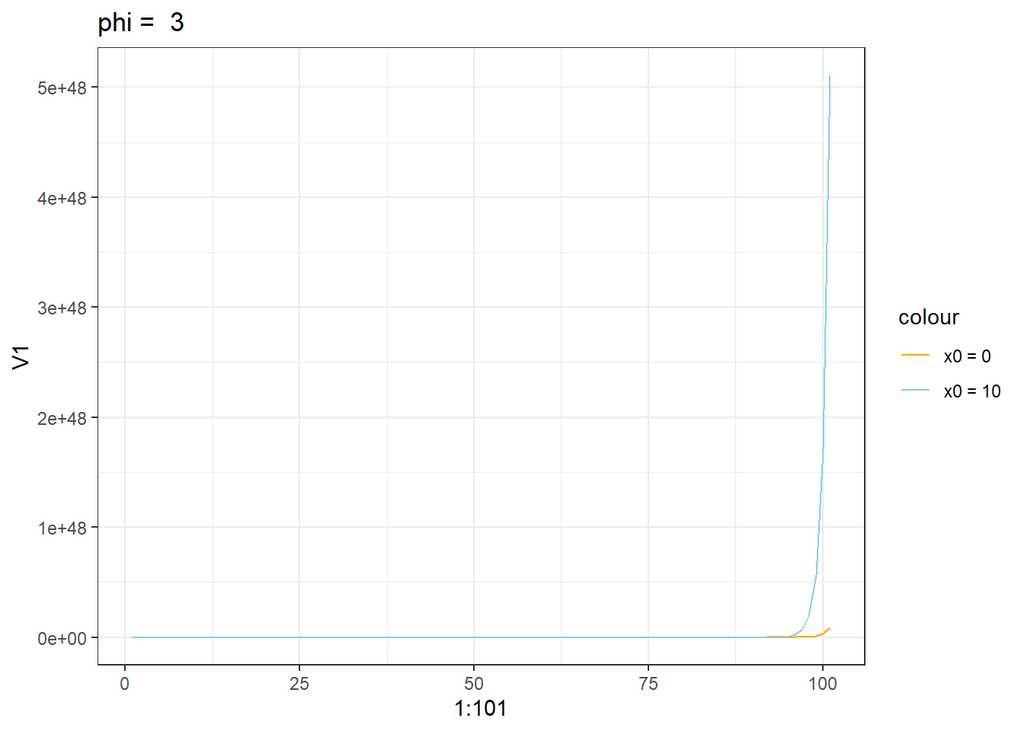

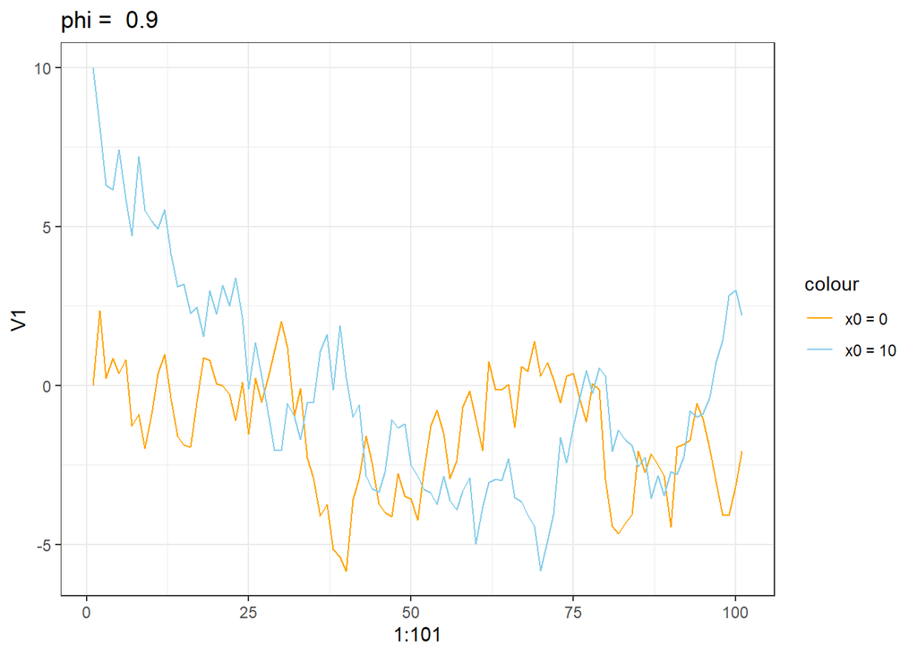

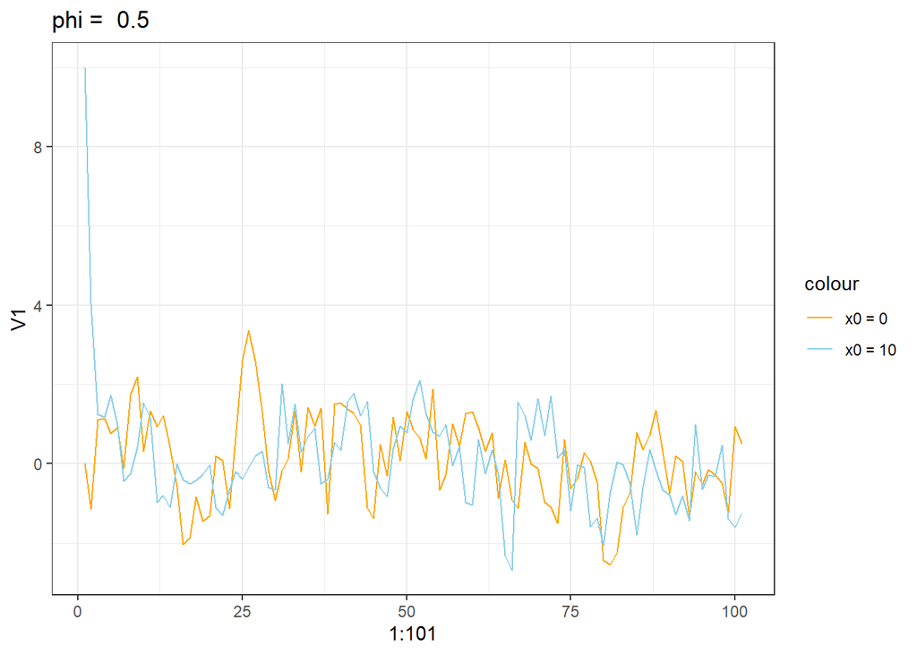

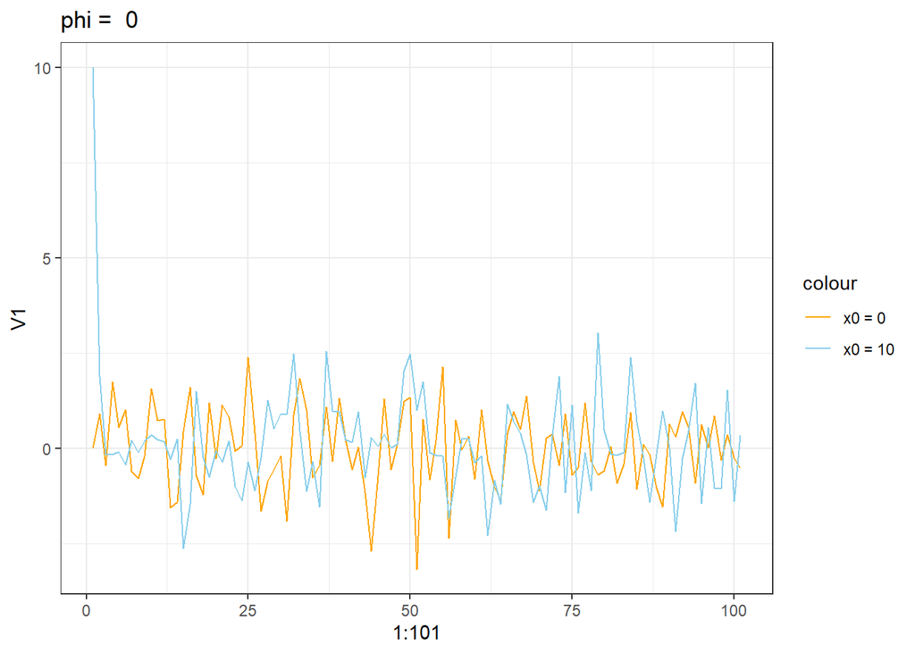

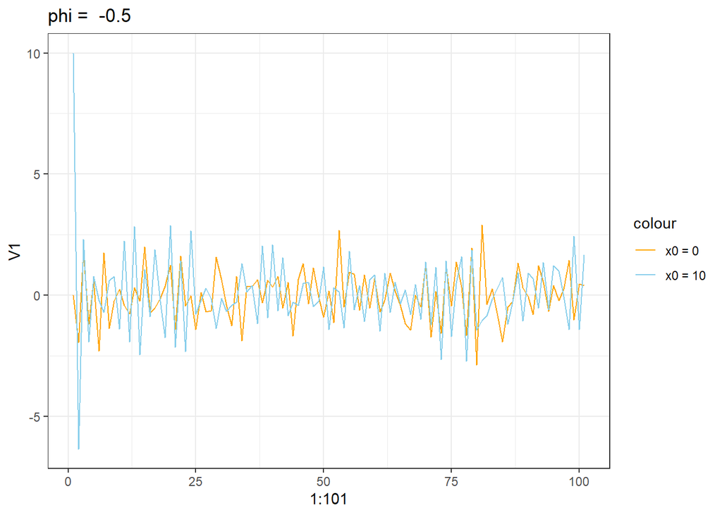

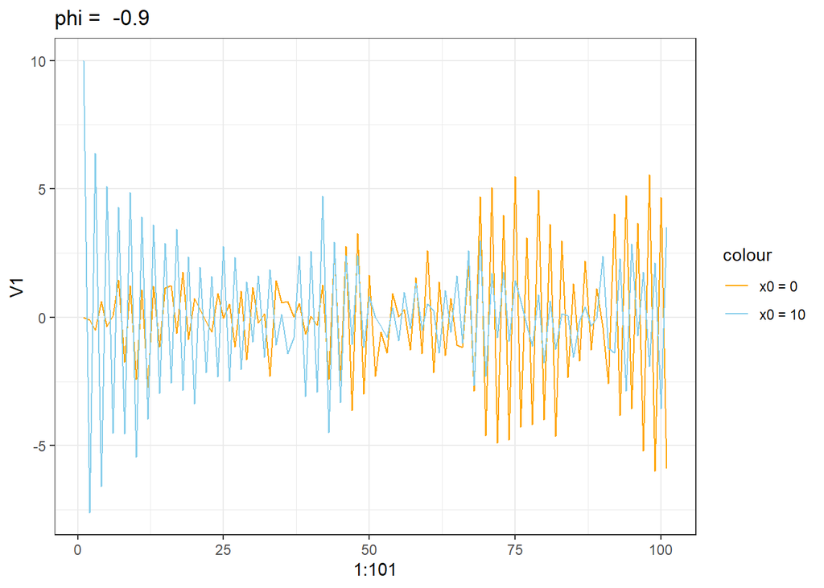

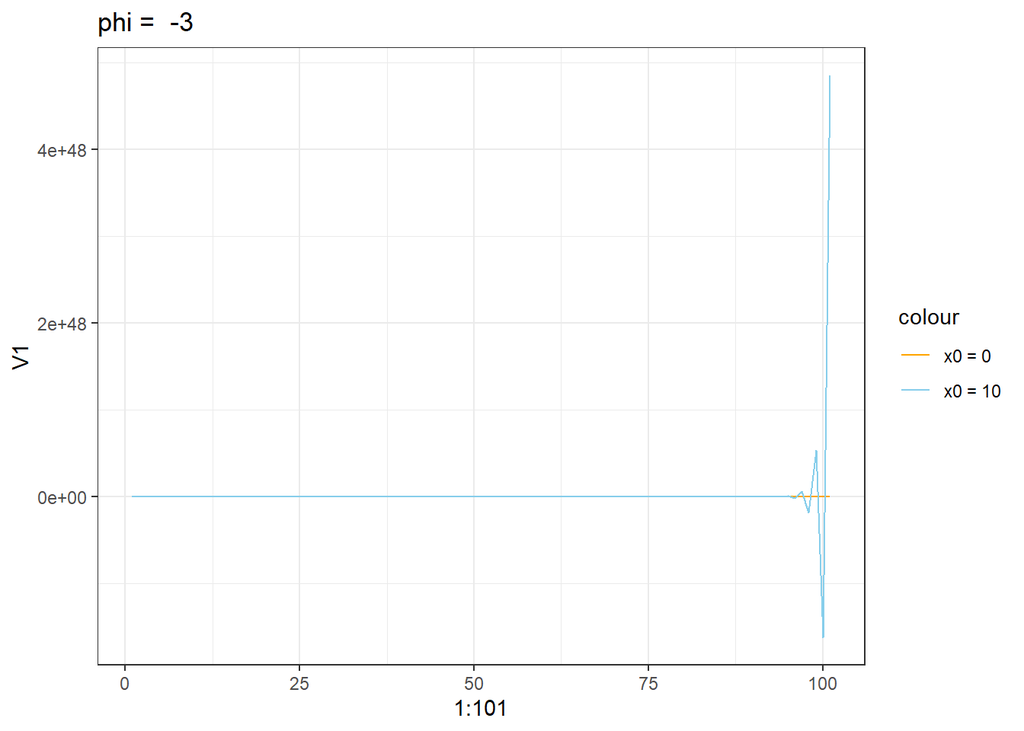

```r
library(ggplot2)
for (i in 1:7){
  print(ggplot(data = as.data.frame(X[,,i])) +
    geom_line(aes(x = 1:101, y = V1, col = "orange")) +
    geom_line(aes(x = 1:101, y = V2, col = "skyblue")) +
    labs(title = paste("phi = ",pi[i])) +
    scale_color_manual(values = c("orange","skyblue"), labels = c("x0 = 0","x0 = 10")))
}
```

## Exercise 4

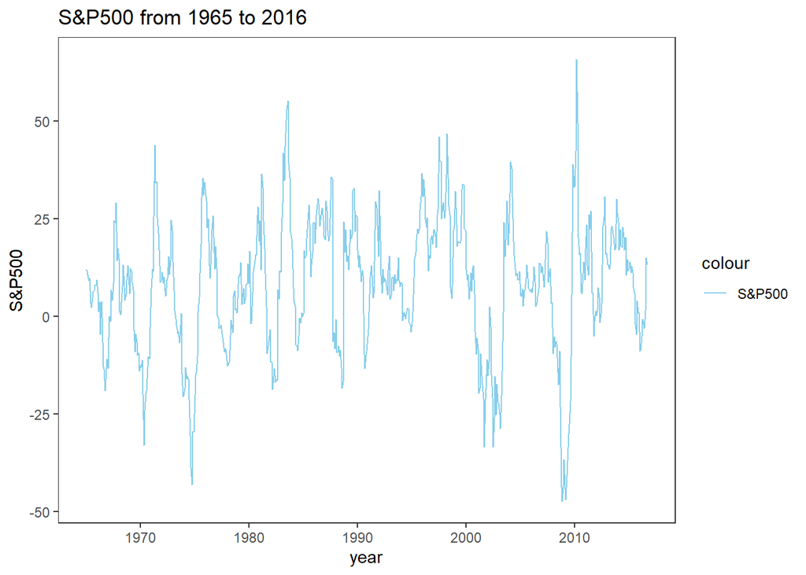

```r
data <- readxl::read_xlsx("USMacroData1965_2016updated.xlsx")
SP <- data[,length(data)]
ggplot(data = data, aes(x = Date, y = `S&P500`)) +
  geom_line(aes(col = "skyblue")) +
  labs(title = "S&P500 from 1965 to 2016",x = "year") +
  scale_color_manual(values = "skyblue", labels = "S&P500") +
  theme(panel.grid = element_blank())
```

Theoretical posterior distribution of $\phi$ is as follow:

$$\phi \mid y_{1:n},\mathbf{F} \sim t_{(n-2)}\left(m(y_{1:n}) , \frac{C(y_{1:n})}{n-2}\right) \\
where \quad m(y_{1:n}) = \frac{\sum_{t=2}^ny_{t-1}y_t}{\sum_{t=1}^{n-1} y_t^2} \\
and \quad C(y_{1:n}) = \frac{\sum_{n=2}^n y_t^2\sum_{n=2}^ny_{t-1}^2 - (\sum_{t=2}^n y_ty_{t-1})^2} {(\sum^{n-1}_{t=1} y_t^2)^2}$$

```r
m <- function(x){
  x_0 = x[1:(length(x)-1)]
  x_1 = x[2:length(x)]
  result = sum(x_0*x_1)/sum(x_1^2)
  return(result)
}
C <- function(x){
  x_0 = x[1:(length(x)-1)]
  x_1 = x[2:length(x)]
  result = (sum(x_0^2)*sum(x_1^2) - sum(x_0*x_1)^2)/sum(x_1^2)^2
  return(result)
}
df <- function(x){
  return(length(x)-2)
}

subseries <- function(x,k){
  result <- data.frame(matrix(rep(0,(2*k+1)*(nrow(x) - 2*k)), ncol = (nrow(x) - 2*k)))
  num = ncol(result)
  for(i in 1:num){
    result[,i] <- x[i:(i+2*k),]
  }
  return(result)
}

credible <- function(x,m,C){
  values <- rt(5000, df = df(x)) * C / df(x) + m
  return(quantile(values, c(0.05,0.95)))
}
```

```r
series_84 <- subseries(SP, 84)
series_84_2 <- apply(series_84, 2, function(x){x - mean(x)})
series_84_date <- as.POSIXct(t(subseries(data[,1],84)[85,]))
intervals <- apply(series_84_2, 2, function(x){credible(x,m(x),C(x))})
```

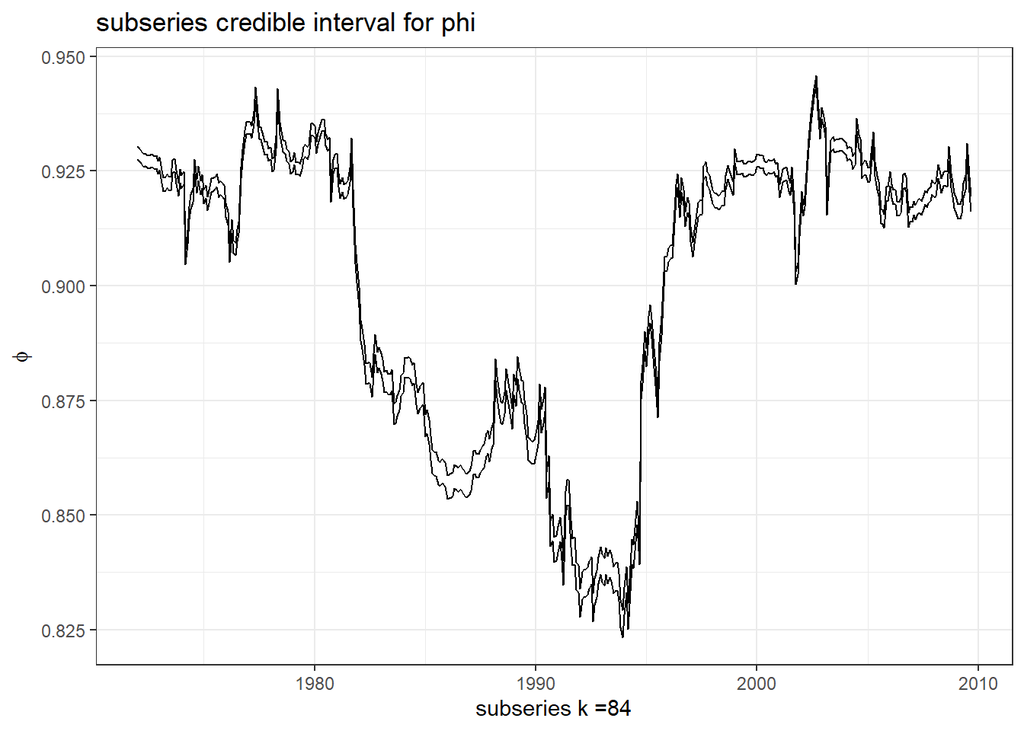

```r
ggplot()+
  geom_line(aes(x = series_84_date, y = intervals[1,])) +
  geom_line(aes(x = series_84_date, y = intervals[2,])) +
  labs(title = "subseries credible interval for phi", y = expression(phi), x = "subseries k =84")
```

#### (a)

Comment on what you see in the plot and comparison, and what you might conclude in terms of changes over time

#### (b)

Do you believe that short-term changes in S&P have shown real changes in month-month dependencies since 1965?

Yes I do, because the short-term is large enough to show stably estimated dependency between $x_t$ and $x_{t-1}$. We can also find that small amplitude during the terms which show small estimated dependency. i.e from 1990 to 1995 in original S&P500 plot. I think this changes show real change in month-month dependency.

#### (c)

How would you suggest also addressing the question of whether or not the underlying mean of the series is stable over time?

Weak stationarity is defined that mean, covariance, varianec is stable or constant over all sub-series process. Thus, as we did before, we can show that mean of the series is stable by showing mean of subseries of the process is stable as below. We can find that mean of series is unstable.

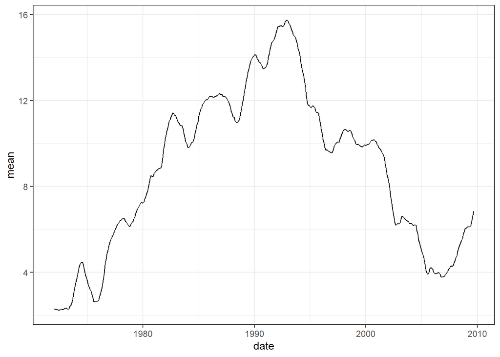

```r
series_84_mean <- apply(series_84, 2, mean)
ggplot()+
  geom_line(mapping = aes(x = series_84_date, y = series_84_mean)) +
  labs(y = "mean", x = "date")
```

#### (d)

What about the innovations variance?

We can show innovation variance’s stability with same way as (c). We can examine variance of subseries which might show innovation variance over time

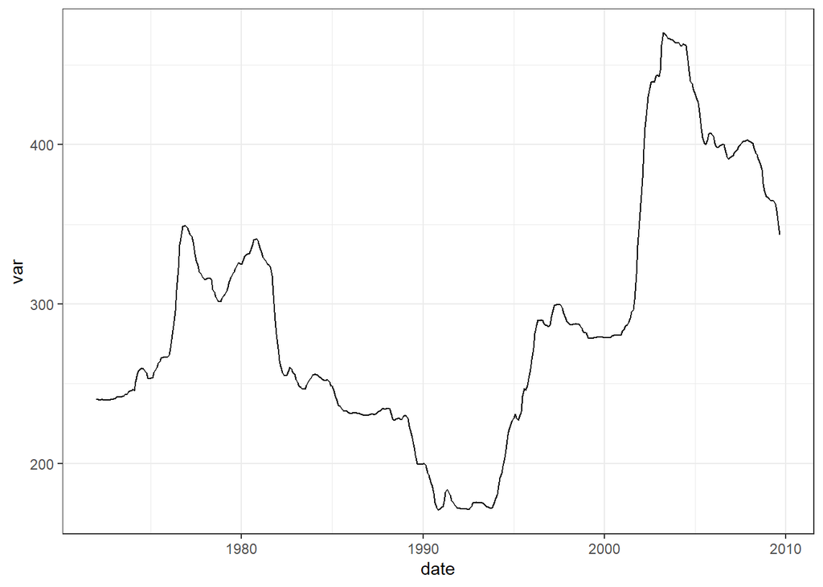

```r
series_84_var <- apply(series_84, 2, function(x){sd(x)^2})
ggplot()+
  geom_line(mapping = aes(x = series_84_date, y = series_84_var)) +
  labs(y = "var", x = "date")
```

#### (e)

What does this suggest for more general models that might do a better job of imitating this data?

This subseries check for parameters can confirm whether parameter we want to estimate is changable or constant. By deciding its changability, we can easily choose appropriate model.

## Exercise 5

Let $\lambda = \nu^{-1}$. Then

$$\begin{aligned}
&\phi \mid \lambda, D_{t-1} \sim N(m_{t-1}, \lambda^{-1}\frac{C_{t-1}}{s_{t-1}}), \quad P(\phi \mid \lambda,D_{t-1}) \propto \lambda^{1/2}exp\{-\frac{\lambda s_{t-1}}{2C_{t-1}}(\phi - m_{t-1})^2 \}\\
&\lambda \mid D_{t-1} \sim G(n_{t-1}/2, n_{t-1}s_{t-1}/2), \quad P(\lambda \mid D_{t-1}) \propto \lambda^{\frac{n_{t-1}}{2} -1} exp\{-\frac{\lambda n_{t-1}s_{t-1}}{2}\} \\
&\rightarrow P(\phi, \lambda \mid D_{t-1}) \propto \lambda^{\frac{n_{t-1}+1}{2} -1} exp\{-\frac{\lambda s_{t-1}}{2}[n_{t-1} + \frac{(\phi - m_{t-1})^2}{C_{t-1}}]\}
\end{aligned}$$

#### (a)

What is the current marginal posterior for $\phi$, namely $P(\phi \mid D_{t-1})$?

$$\begin{aligned}
P(\phi \mid D_{t-1}) &= \int P(\phi \mid \lambda, D_{t-1})P(\lambda \mid D_{t-1})d\lambda \\
&\propto \lambda^{\frac{n_{t-1}+1}{2} -1} exp\{-\frac{\lambda s_{t-1}}{2}[n_{t-1} + \frac{(\phi - m_{t-1})^2}{C_{t-1}}]\} \\
&= \Gamma \left(\frac{n_{t-1}+1}{2} \right) \left[\frac{s_{t-1}}{2}(n_{t-1} + \frac{(\phi - m_{t-1})^2}{C_{t-1}}) \right]^{-\frac{n_{t-1}+1}{2}} \int \Gamma \left(\frac{n_{t-1}+1}{2} \right)^{-1} \left[\frac{s_{t-1}}{2}(n_{t-1} + \frac{(\phi - m_{t-1})^2}{C_{t-1}}) \right]^{\frac{n_{t-1}+1}{2}} \lambda^{\frac{n_{t-1}+1}{2} -1} exp\{-\frac{\lambda s_{t-1}}{2}[n_{t-1} + \frac{(\phi - m_{t-1})^2}{C_{t-1}}]\} \\
&\propto \left[ \frac{s_{t-1}}{2} (n_{t-1} + \frac{(\phi - m_{t-1})^2}{C_{t-1}})\right]^{-\frac{n_{t-1}+1}{2}} \\
&\propto \left[1+\frac{(\phi - m_{t-1})^2}{n_{t-1}C_{t-1}} \right] ^{-\frac{n_{t-1}+1}{2}} \rightarrow \phi \sim t(n_{t-1}, m_{t-1}, C_{t-1})
\end{aligned}$$
That is $\frac{(\phi - m_{t-1})^2}{C_{t-1}} \sim t_{n_{t-1}}$ with $n_{t-1}$ degree of freedom

#### (b)

Show that, conditional on v and marginalizing over $\phi$, the implied 1−step ahead forecast distribution for $x_t$ given v is $(x_t \mid \nu, D_{t-1}) \sim N(f_t, q_t\nu/s_{t-1})$ with $f_t = m_{t-1}x_{t-1}$ and $q_t = s_{t-1} + C_{t-1}x_{t-1}^2$.

Let $\frac{s_{t-1}}{C_{t-1}} = k$. Then
$$\begin{aligned}
x_t \mid \phi, \lambda, D_{t-1} \sim N(\phi x_{t-1}, \lambda^{-1}) \\ \rightarrow P(x_t \mid \phi, \lambda, D_{t-1}) =\lambda^{1/2}exp\{-\frac{\lambda}{2}(x_t - \phi x_{t-1})^2 \} \\
P(\phi \mid \lambda,D_{t-1}) \propto \lambda^{1/2}exp\{-\frac{\lambda k}{2}(\phi - m_{t-1})^2\}
\end{aligned}$$
Then,

$$\begin{aligned}
P(x_t \mid \lambda, D_{t-1}) &= \int P(x_t\mid\phi,\lambda,D_{t-1})P(\phi\mid\lambda,D_{t-1})d\phi \\
&\propto \int \lambda exp\{-\frac{\lambda}{2}(\phi^2(x_{t-1}^2 +k) - 2\phi(x_tx_{t-1} +km_{t-1}) +x_t^2 +km_{t-1}^2)\} d\phi \\
&\propto \lambda^{1/2}exp\{-\frac{\lambda}{2}(x_t^2 + km_{t-1}^2 - \frac{(x_tx_{t-1} + km_{t-1})^2}{x_{t-1}^2 +k})\} \int \lambda^{1/2}exp\{-\frac{\lambda(x_{t-1}^2 +k)}{2}(\phi^2 - 2\phi(\frac{x_tx_{t-1} + km_{t-1}}{x_{t-1}^2 +k}) + (\frac{x_tx_{t-1} + km_{t-1}}{x_{t-1}^2 +k})^2)\}d\phi \\
&\propto \lambda^{1/2}exp\{-\frac{\lambda}{2}(x_t^2 + km_{t-1}^2 - \frac{(x_tx_{t-1} + km_{t-1})^2}{x_{t-1}^2 +k})\} \\
&\propto \lambda^{1/2}exp\{-\frac{\lambda}{2}(x_t^2(1-\frac{x_{t-1}^2}{x_{t-1}^2+k}) -2x_t\frac{kx_{t-1}m_{t-1}}{x_{t-1}^2+k} + km_{t-1}^2(1 - \frac{k}{x_{t-1}^2+k})) \} \\
&\propto \lambda^{1/2}exp\{\frac{\lambda k}{2(x_{t-1}^2+k)} (x_t^2 - 2x_tx_{t-1}m_{t-1} + x_{t-1}^2m_{t-1}^2)\} \\
&\rightarrow x_t \sim N(x_{t-1}m_{t-1}, \lambda^{-1}(1+x_{t-1}/k)),\quad where\; \lambda^{-1}(1+x_{t-1}/k)) = \nu(1+ \frac{C_{t-1}}{s_{t-1}}x_{t-1}^2) = \frac{\nu}{s_{t-1}}q_t\\
&\rightarrow x_t \sim N(f_t, q_tv/s_{t-1})
\end{aligned}$$

#### (c)

Now marginalize also over v to find the implied 1−step ahead forecast distribution for $P(x_t\mid D_{t-1})$, i.e., the distribution you will use in practice to predict $x_t$ 1−step ahead. What is this distribution?

$P(x_t \mid \lambda,D_{t-1}) \propto \lambda^{1/2}exp\{-\frac{\lambda k}{2(x_{t-1}^2+k)}(x_t - x_{t-1}m_{t-1})^2\}$ then,
$$\begin{aligned}
P(x_t \mid D_{t-1}) &\propto \int P(x_t \mid \lambda, D_{t-1})P(\lambda \mid D_{t-1})d\lambda \\
&\propto \int \lambda^{\frac{n_{t-1}+1}{2} -1} exp\{-\frac{\lambda}{2} \left[n_{t-1}s_{t-1} + \frac{k}{x_{t-1}^2 +k}(x_t - x_{t-1}m_{t-1})^2 \right]\} \\
&\propto \left[n_{t-1}s_{t-1} + \frac{k}{x_{t-1}^2+k}(x_t - x_{t-1}m_{t-1})^2\right]^{-\frac{n_{t-1} +1}{2}} \\
&\propto \left[1 + 1/n_{t-1} \times 1/(C_{t-1}x_{t-1}^2 + s_{t-1}) \times (x_t - x_{t-1}m_{t-1})^2 \right] ^{-\frac{n_{t-1} +1}{2}} \\
&\rightarrow x_t \sim t(n_{t-1}, x_{t-1}m_{t-1}, C_{t-1}x_{t-1}^2 + s_{t-1})
\end{aligned}$$

#### (d)

Show that the time t posterior $p(\phi, \nu|D_t)$ is also normal-inverse gamma, having the same form as in at time t − 1 above but now with t − 1 updated to t and updated defining parameters $m_t,C_t,n_t,s_t$ that can be written in the following forms: $m_t = m_{t-1} + A_te_t$ $C_t = r_{t}(C_{t-1} - A^2_tq_t)$ $n_t = n_{t-1}+1$ $s_t = r_ts_{t-1}$ where $e_t = x_t - f_t$ and $A_t = C_{t-1}x_{t-1}/q_t$

$$\begin{aligned}
P(\phi, \lambda \mid D_t) &= P(\phi, \lambda \mid x_t,D_{t-1}) \\
&= \frac{P(\phi,\lambda,x_t \mid D_{t-1})}{P(x_t \mid D_{t-1})} \\
&= \frac{p(x_t \mid \phi, \lambda, D_{t-1})P(\phi \mid \lambda, D_{t-1})P(\lambda \mid D_{t-1})}{P(x_t \mid D_{t-1})} \\
&\propto \frac{\lambda^{1/2}exp\{-\frac{\lambda(x_t - \phi x_{t-1})^2}{2}\} (\lambda k)^{1/2}exp\{-\frac{\lambda k(\phi - m_{t-1})^2}{2} \lambda^{n_{t-1}/2}\}exp\{-\frac{\lambda n_{t-1}s_{t-1}}{2} \}}{[1+ \frac{x_t - x_{t-1}m_{t-1}}{n_{t-1} \times (C_{t-1}x_{t-1}^2 + s_{t-1})}]^{-\frac{n_{t-1} +1}{2}}} \\
&\propto \lambda^{1/2}exp\{-\frac{\lambda(x_t - \phi x_{t-1})^2}{2}\} (\lambda k)^{1/2}exp\{-\frac{\lambda k(\phi - m_{t-1})^2}{2} \lambda^{n_{t-1}/2}\}exp\{-\frac{\lambda n_{t-1}s_{t-1}}{2} \} \\
&= (\lambda k)^{1/2}exp\{-\frac{\lambda k }{2} (\phi^2 - 2m_{t-1}\phi + \phi^2x_{t-1}/k -2\phi x_t x_{t-1}/k)\} \times \lambda^{n_{t-1}+1/2}exp\{-\frac{\lambda}{2}(n_{t-1}s_{t-1} + km_{t-1}^2 + x_t^2)\} \\
&= (\lambda k)^{1/2}exp\{-\frac{\lambda (k+x_{t-1}^2)}{2}(\phi^2 - 2\phi\frac{km_{t-1}+x_tx_{t-1}}{k+x_{t-1}^2} + (\frac{km_{t-1}+x_tx_{t-1}}{k+x_{t-1}^2})^2)\} \times \lambda^{n_{t-1}+1/2}exp\{-\frac{\lambda}{2}(n_{t-1}+s_{t-1} + km_{t-1}^2 + x_t^2 - \frac{(km_{t-1} + x_tx_{t-1})^2}{k+x_{t-1}^2}) \} \\
&\rightarrow P(\phi \mid \lambda, D_t)P(\lambda \mid D_t) \\
&P(\phi \mid \lambda, D_t) \sim N(\frac{km_{t-1} + x_tx_{t-1}}{k+x_{t-1}^2}, \frac{\nu}{k+x_{t-1}^2}), \quad P(\lambda \mid D_t) \sim Gamma(\frac{n_{t-1}+1}{2}, (n_{t-1}+s_{t-1} + km_{t-1}^2 + x_t^2 - \frac{(km_{t-1}+x_tx_{t-1})^2}{k+x_{t-1}^2}))
\end{aligned}$$
we can find that

$$\begin{aligned}
n_t &= n_{t-1} +1 \\
n_ts_t &= n_{t-1}s_{t-1} + km_{t-1}^2 + x_t^2 - \frac{k^2m_{t-1}^2 + 2km_{t-1}x_tx_{t-1} + x_t^2x_{t-1}^2}{k+x_{t-1}^2} \\
&= n_{t-1}s_{t-1} + \frac{1}{k+x_{t-1}^2}(k^2m_{t-1}^2 + km_{t-1}^2x_{t-1}^2 + kx_t^2 + x_t^2x_{t-1}^2 - k^2m_{t-1}^2 - 2km_{t-1}x_tx_{t-1} - x_t^2x_{t-1}^2) \\
&= n_{t-1}s_{t-1} + \frac{k}{k+x_{t-1}^2}(x_t - m_{t-1}x_{t-1})^2 \\
&= n_{t-1}s_{t-1} + \frac{s_{t-1}}{s_{t-1} + C_{t-1}x_{t-1}^2}(x_t - m_{t-1}x_{t-1})^2 \\
&= s_{t-1}(n_{t-1} + \frac{e_t^2}{q_t}) \\
&\rightarrow s_t = \frac{s_{t-1}}{n_t}(n_{t-1} + \frac{e_t^2}{q_t}) \\
\\
C_t &= s_t/(k+x_{t-1}^2) = r_ts_{t-1}/(k+x_{t-1}^2) = r_tC_{t-1}s_{t-1}/q_t = r_t(C_{t-1} - A_t^2q_t) \\
\\
m_t &= \frac{km_{t-1} + x_tx_{t-1}}{k+x_{t-1}^2} \\
&= \frac{s_{t-1}m_{t-1} + C_{t-1}x_tx_{t-1}}{s_{t-1}+ C_{t-1}+x_{t-1}^2} \\
&= m_{t-1} + \frac{C_{t-1}x_tx_{t-1} - m_{t-1}C_{t-1}x_{t-1}^2}{s_{t-1} + C_{t-1} + x_{t-1}^2} \\
&= m_{t-1} + \frac{C_{t-1}x_{t-1}(x_t - m_{t-1}x_{t-1})}{s_{t-1}+C_{t-1} + x_{t-1}^2} = m_{t-1} + A_te_t
\end{aligned}$$

from above factorized pdf

#### (e)

i,ii. Above expression, $m_t = m_{t-1} + A_te_t$ shows that $m_t$ depends on $x_t$ as much as adaptive coefficent $A_t$ relative to prior mean. In my opinion, $r_t$ is indicator of how much uncertainty of process is changed by new observation by introducing realized error. With $r_t$, $C_t$ depends on $C_{t-1}$ and we can confirm that $C_t$ was reduced by adaptive coefficient square $A_t^2$ and $q_t$ which can only positive values. That means , in the case of forecast error is not that large, $C_t$ is reduced by new observations.

3. We can find that $n_t$ is increased as much as the number of new observations $x_t$. For $s_t$, it is affected indirectly by $x_t$ by forecast error $e_t = x_t - f_t$. If forecast error is large which means realized $x_t$ is largely different from what expected, $s_t$ is increased. On the contrary, if $x_t$ is similar with our expectation, $s_t$ would be reduced.

#### (f)

In the case that the forecast error is so large that $e^2_t/q_t$ is larger than 1, $s_t$ which is point estimator of innovation variance would be increased. Moreover, since $C_t$ depends on $s_t$, it would be also increased. As result, the uncertainty of posterior distribution of $(\phi, \nu)$ would increase.